# Decision Tree

CART (Classification and Regression Tree)

## What is Decision Tree?

[figure not shown]

- Supervised Learning
- Works for both classification and regression
- Foundation of Random Forests
- Attractive because of interpretability

Decision Tree works by:

- Split based on set impurity criteria
- Stopping criteria

Source: [Scikit-Learn](http://scikit-learn.org/stable/modules/tree.html#tree)

Some **advantages** of decision trees are:

- Simple to understand and to interpret. Trees can be visualised.
- Requires little data preparation.
- Able to handle both numerical and categorical data.
- Possible to validate a model using statistical tests.
- Performs well even if its assumptions are somewhat violated by the true model from which the data were generated.

The **disadvantages** of decision trees include:

- Overfitting. Mechanisms such as pruning (not currently supported), setting the minimum number of samples required at a leaf node or setting the maximum depth of the tree are necessary to avoid this problem.
- Decision trees can be unstable. Mitigant: Use decision trees within an ensemble.
- Cannot guarantee to return the globally optimal decision tree. Mitigant: Training multiple trees in an ensemble learner
- Decision tree learners create biased trees if some classes dominate. Recommendation: Balance the dataset prior to fitting

## Questions:

1. What is a decision tree?
2. Where can you apply decision tree to? numerical problems or categorical problems?
3. Decision tree is also know by what other name?
4. How does a decision tree work?
5. Decision Tree is a foundation of what machine learning algorithm
6. List and explain 3 advantages of decision tree
7. List and explain 3 disadvantages of decision tree

# Classification

## Training a Decision Tree with Scikit-Learn Library

```python
from sklearn import tree
```

```python
X = [[0, 0], [1, 2]]
y = [0, 1]
```

```python
clf = tree.DecisionTreeClassifier()
```

```python
clf = clf.fit(X, y)
```

```python
clf.predict([[2., 2.]])
```

```
array([1])
```

```python
clf.predict_proba([[2. , 2.]])
```

```
array([[ 0.,  1.]])
```

```python
clf.predict([[0.4, 1.2]])
```

```
array([0])
```

```python
clf.predict_proba([[0.4, 1.2]])
```

```
array([[ 1.,  0.]])
```

```python
clf.predict_proba([[0, 0.2]])
```

```
array([[ 1.,  0.]])
```

`DecisionTreeClassifier` is capable of both binary (where the labels are [-1, 1]) classification and multiclass (where the labels are [0, …, K-1]) classification.

## Applying to Iris Dataset

```python
from sklearn.datasets import load_iris
from sklearn import tree
iris = load_iris()
```

```python
iris.data[0:5]
```

```
array([[ 5.1,  3.5,  1.4,  0.2],
       [ 4.9,  3. ,  1.4,  0.2],
       [ 4.7,  3.2,  1.3,  0.2],
       [ 4.6,  3.1,  1.5,  0.2],
       [ 5. ,  3.6,  1.4,  0.2]])
```

```python
iris.feature_names
```

```
['sepal length (cm)',
 'sepal width (cm)',
 'petal length (cm)',
 'petal width (cm)']
```

```python
X = iris.data[:, 2:]
```

```python
y = iris.target
```

```python
y
```

```
array([0, 0, 0, 0, 0, 0, 0, 0, 0, 0, 0, 0, 0, 0, 0, 0, 0, 0, 0, 0, 0, 0, 0,
       0, 0, 0, 0, 0, 0, 0, 0, 0, 0, 0, 0, 0, 0, 0, 0, 0, 0, 0, 0, 0, 0, 0,
       0, 0, 0, 0, 1, 1, 1, 1, 1, 1, 1, 1, 1, 1, 1, 1, 1, 1, 1, 1, 1, 1, 1,
       1, 1, 1, 1, 1, 1, 1, 1, 1, 1, 1, 1, 1, 1, 1, 1, 1, 1, 1, 1, 1, 1, 1,
       1, 1, 1, 1, 1, 1, 1, 1, 2, 2, 2, 2, 2, 2, 2, 2, 2, 2, 2, 2, 2, 2, 2,
       2, 2, 2, 2, 2, 2, 2, 2, 2, 2, 2, 2, 2, 2, 2, 2, 2, 2, 2, 2, 2, 2, 2,
       2, 2, 2, 2, 2, 2, 2, 2, 2, 2, 2, 2])
```

```python
clf = tree.DecisionTreeClassifier(random_state=42)
```

```python
clf = clf.fit(X, y)
```

### Export_graphviz

```python
from sklearn.tree import export_graphviz
```

```python
export_graphviz(clf,
                out_file="tree.dot",
                feature_names=iris.feature_names[2:],
                class_names=iris.target_names,
                rounded=True,
                filled=True)
```

Run the following line on your command prompt

`$ dot -Tpng tree.dot -o tree.png`

[figure not shown]

## Graphviz

```python
import graphviz
```

```python
dot_data = tree.export_graphviz(clf, out_file=None,
                                feature_names=iris.feature_names[2:],
                                class_names=iris.target_names,
                                rounded=True,
                                filled=True)
```

```python
graph = graphviz.Source(dot_data)
```

```python
graph
```

[figure not shown]

## Visualise the Decision Boundary

```python
import numpy as np
import seaborn as sns
sns.set_style('whitegrid')
import matplotlib.pyplot as plt
%matplotlib inline
```

```python
df = sns.load_dataset('iris')
df.head()
```

|  | sepal_length | sepal_width | petal_length | petal_width | species |
| --- | --- | --- | --- | --- | --- |
| 0 | 5.1 | 3.5 | 1.4 | 0.2 | setosa |
| 1 | 4.9 | 3.0 | 1.4 | 0.2 | setosa |
| 2 | 4.7 | 3.2 | 1.3 | 0.2 | setosa |
| 3 | 4.6 | 3.1 | 1.5 | 0.2 | setosa |
| 4 | 5.0 | 3.6 | 1.4 | 0.2 | setosa |

```python
col = ['petal_length', 'petal_width']
X = df.loc[:, col]
```

```python
species_to_num = {'setosa': 0,
                  'versicolor': 1,
                  'virginica': 2}
df['tmp'] = df['species'].map(species_to_num)
y = df['tmp']
```

```python
clf = tree.DecisionTreeClassifier()
clf = clf.fit(X, y)
```

```python
Xv = X.values.reshape(-1,1)
h = 0.02
x_min, x_max = Xv.min(), Xv.max() + 1
y_min, y_max = y.min(), y.max() + 1
xx, yy = np.meshgrid(np.arange(x_min, x_max, h),
                     np.arange(y_min, y_max, h))
```

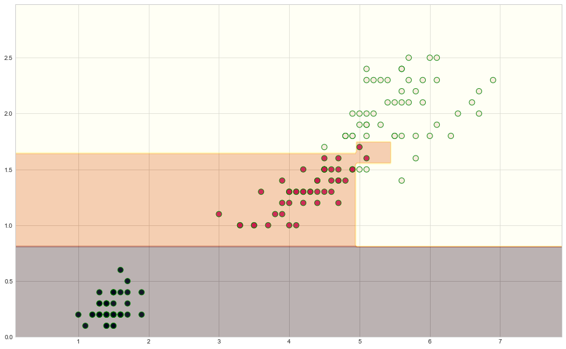

```python
z = clf.predict(np.c_[xx.ravel(), yy.ravel()])
z = z.reshape(xx.shape)
fig = plt.figure(figsize=(16,10))
ax = plt.contourf(xx, yy, z, cmap = 'afmhot', alpha=0.3);
plt.scatter(X.values[:, 0], X.values[:, 1], c=y, s=80,
            alpha=0.9, edgecolors='g');
```

# Decision Tree Learning

- [ID3](https://en.wikipedia.org/wiki/ID3_algorithm) (Iterative Dichotomiser 3)
- [C4.5](https://en.wikipedia.org/wiki/C4.5_algorithm) (successor of ID3)
- CART (Classification And Regression Tree)
- [CHAID](http://www.statisticssolutions.com/non-parametric-analysis-chaid/) (Chi-squared Automatic Interaction Detector). by [Gordon Kass](https://en.wikipedia.org/wiki/Chi-square_automatic_interaction_detection).

## Tree algorithms: ID3, C4.5, C5.0 and CART

- ID3 (Iterative Dichotomiser 3) was developed in 1986 by Ross Quinlan. The algorithm creates a multiway tree, finding for each node (i.e. in a greedy manner) the categorical feature that will yield the largest information gain for categorical targets. Trees are grown to their maximum size and then a pruning step is usually applied to improve the ability of the tree to generalise to unseen data.
- C4.5 is the successor to ID3 and removed the restriction that features must be categorical by dynamically defining a discrete attribute (based on numerical variables) that partitions the continuous attribute value into a discrete set of intervals. C4.5 converts the trained trees (i.e. the output of the ID3 algorithm) into sets of if-then rules. These accuracy of each rule is then evaluated to determine the order in which they should be applied. Pruning is done by removing a rule’s precondition if the accuracy of the rule improves without it.
- C5.0 is Quinlan’s latest version release under a proprietary license. It uses less memory and builds smaller rulesets than C4.5 while being more accurate.
- CART (Classification and Regression Trees) is very similar to C4.5, but it differs in that it supports numerical target variables (regression) and does not compute rule sets. CART constructs binary trees using the feature and threshold that yield the largest information gain at each node.
- CHAID (Chi-squared Automatic Interaction Detector). by Gordon Kass. Performs multi-level splits when computing classification trees. Non-parametric. Does not require the data to be normally distributed.

scikit-learn uses an optimised version of the CART algorithm.

# Gini Impurity

scikit-learn default

[Gini Impurity](https://en.wikipedia.org/wiki/Decision_tree_learning#Gini_impurity)

A measure of purity / variability of categorical data

As a side note on the difference between [Gini Impurity and Gini Coefficient](https://datascience.stackexchange.com/questions/1095/gini-coefficient-vs-gini-impurity-decision-trees)

- No, despite their names they are not equivalent or even that similar.
- **Gini impurity** is a measure of misclassification, which applies in a multiclass classifier context.
- **Gini coefficient** applies to binary classification and requires a classifier that can in some way rank examples according to the likelihood of being in a positive class.
- Both could be applied in some cases, but they are different measures for different things. Impurity is what is commonly used in decision trees.

Developed by [Corrado Gini](https://en.wikipedia.org/wiki/Corrado_Gini) in 1912

Key Points:

- A pure node (homogeneous contents or samples with the same class) will have a Gini coefficient of zero
- As the variation increases (heterogeneneous classes or increase diversity), Gini coefficient increases and approaches 1.

$$Gini=1-\sum^r_j p^2_j$$

$p$ is the probability (often based on the frequency table)

[figure not shown]

# Entropy

Wikipedia

The entropy can explicitly be written as

$${\displaystyle \mathrm {H} (X)=\sum _{i=1}^{n}{\mathrm {P} (x_{i})\,\mathrm {I} (x_{i})}=-\sum _{i=1}^{n}{\mathrm {P} (x_{i})\log _{b}\mathrm {P} (x_{i})},}$$

where `b` is the base of the logarithm used. Common values of `b` are 2, Euler's number `e`, and 10

# Which should I use?

[Sebastian Raschka](https://sebastianraschka.com/faq/docs/decision-tree-binary.html)

- They tend to generate similar tree
- Gini tends to be faster to compute

```python
def gini(p):
    return (p)*(1 - (p)) + (1 - p)*(1 - (1-p))
def entropy(p):
    return - p*np.log2(p) - (1 - p)*np.log2((1 - p))
def error(p):
    return 1 - np.max([p, 1 - p])
```

```python
x = np.arange(0.0, 1.0, 0.01)

ent = [entropy(p) if p != 0 else None for p in x]

sc_ent = [e*0.5 if e else None for e in ent]
err = [error(i) for i in x]
```

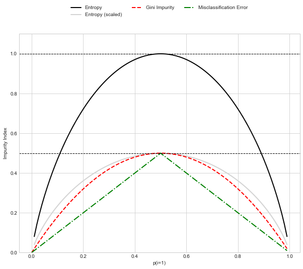

```python
fig = plt.figure(figsize=(10,8))
ax = plt.subplot(111)
for i, lab, ls, c, in zip([ent, sc_ent, gini(x), err],
                   ['Entropy', 'Entropy (scaled)',
                   'Gini Impurity',
                   'Misclassification Error'],
                   ['-', '-', '--', '-.'],
                   ['black', 'lightgray',
                      'red', 'green', 'cyan']):
     line = ax.plot(x, i, label=lab,
                    linestyle=ls, lw=2, color=c)
ax.legend(loc='upper center', bbox_to_anchor=(0.5, 1.15),
           ncol=3, fancybox=True, shadow=False)
ax.axhline(y=0.5, linewidth=1, color='k', linestyle='--')
ax.axhline(y=1.0, linewidth=1, color='k', linestyle='--')
plt.ylim([0, 1.1])
plt.xlabel('p(i=1)')
plt.ylabel('Impurity Index')
plt.show()
```

# Information Gain

- Expected reduction in entropy caused by splitting
- Keep splitting until you obtain a as close to homogeneous class as possible